# Ecology - Appendix S2 : Phenotypic plasticity of ‘off-host’ parasite stages in response to heatwaves in the Daphnia-Pasteuria system

#### Visualisation

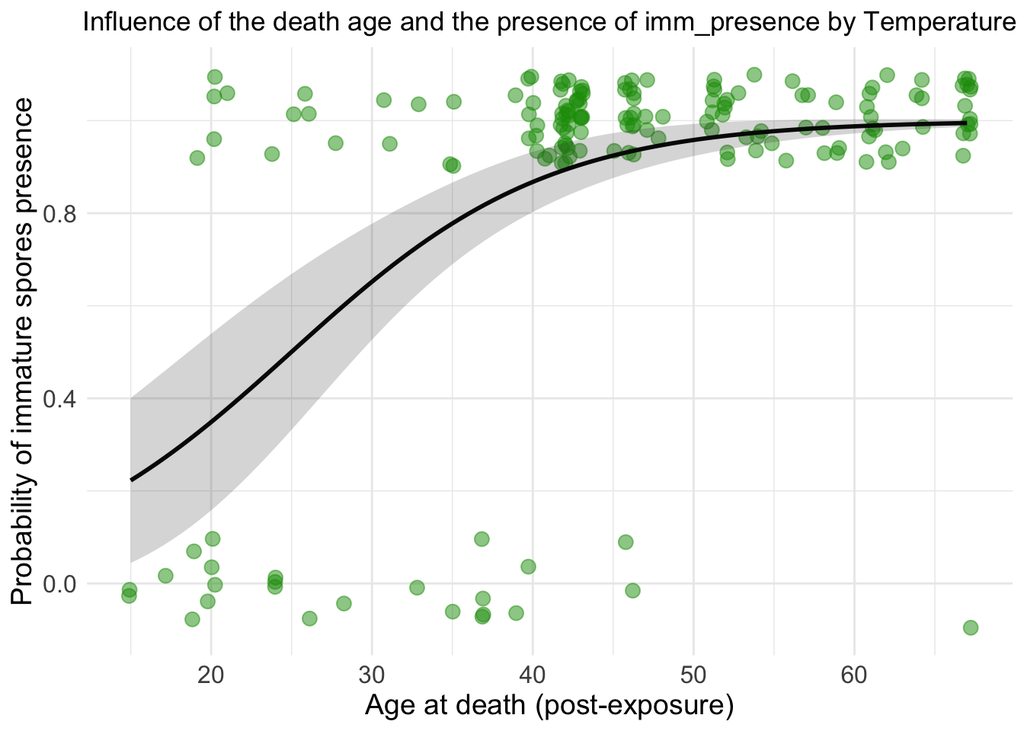

### 5.4 Mature spores

Spores reach their final maturation stage and can now infect new hosts. We are interested in understanding how individual mature parasite load is affected by temperature and/or the genotype of the spores. We also investigated the potential impact of variations in time post-exposure, as all screened individuals died at different times.

```r
data_mat = subset(infected, infected$mature_load>0)
data_mat$Temperature = factor(data_mat$Temperature, ordered = F)

mat1 = glmmTMB(data=data_mat, mature_load/10000000~Temperature*Isolate*DeathAge, family = "gaussian", REML=T)
mat1R = glmmTMB(data=data_mat, mature_load/10000000~Temperature*Isolate*DeathAge+(1|Batch), family = "gaussian", REML=T)

AICc(mat1, mat1R) # No need of a batch effect
```

```
##       df     AICc
## mat1  25 242.8509
## mat1R 26 245.6588
```

```r
mat2 = glmmTMB(data=data_mat, mature_load/10000000~Temperature+Isolate*DeathAge, family = "gaussian")
mat3 = glmmTMB(data=data_mat, mature_load/10000000~Temperature*Isolate+DeathAge, family = "gaussian")
mat4 = glmmTMB(data=data_mat, mature_load/10000000~Isolate+DeathAge*Temperature, family = "gaussian")

mat5 = glmmTMB(data=data_mat, mature_load/10000000~Isolate*DeathAge, family = "gaussian")
mat6 = glmmTMB(data=data_mat, mature_load/10000000~Temperature*Isolate, family = "gaussian")
mat7 = glmmTMB(data=data_mat, mature_load/10000000~Temperature*DeathAge, family = "gaussian")

mat8 = glmmTMB(data=data_mat, mature_load/10000000~Temperature+Isolate+DeathAge, family = "gaussian")

mat9 = glmmTMB(data=data_mat, mature_load/10000000~Isolate+DeathAge, family = "gaussian")
mat10 = glmmTMB(data=data_mat, mature_load/10000000~Temperature+Isolate, family = "gaussian")
mat11 = glmmTMB(data=data_mat, mature_load/10000000~Temperature+DeathAge, family = "gaussian")

mat12 = glmmTMB(data=data_mat, mature_load/10000000~DeathAge, family = "gaussian")
mat13 = glmmTMB(data=data_mat, mature_load/10000000~Isolate, family = "gaussian")
mat14 = glmmTMB(data=data_mat, mature_load/10000000~Temperature, family = "gaussian")

mat0 = glmmTMB(data=data_mat, mature_load/10000000~1, family = "gaussian")

AICc(mat1, mat2, mat3, mat4, mat5, mat6, mat7, mat8, mat9, mat10, mat11, mat12, mat13, mat14, mat0)
```

```
##       df      AICc
## mat1  25 242.85092
## mat2  11  97.42244
## mat3  14 104.23161
## mat4  10  99.48683
## mat5   9  93.04474
## mat6  13 150.21483
## mat7   7 107.51440
## mat8   8  96.60519
## mat9   6  92.28979
## mat10  7 139.42053
## mat11  5 104.35369
## mat12  3 100.24447
## mat13  5 136.94938
## mat14  4 154.88560
## mat0   2 152.62650
```

```r
tab_model(mat9, mat5, show.intercept = F)
```

|  | mature_load/1e+07 |  |  | mature_load/1e+07 |  |  |
| --- | --- | --- | --- | --- | --- | --- |
| Predictors | Estimates | CI | p | Estimates | CI | p |
| Isolate [C1] | 0.09 | -0.07 – 0.24 | 0.286 | -0.70 | -1.46 – 0.06 | 0.071 |
| Isolate [C18] | 0.28 | 0.13 – 0.43 | **<0.001** | -0.44 | -1.10 – 0.22 | 0.189 |
| Isolate [C24] | 0.09 | -0.07 – 0.24 | 0.286 | -0.35 | -1.03 – 0.33 | 0.308 |
| DeathAge | 0.02 | 0.01 – 0.02 | **<0.001** | 0.01 | -0.00 – 0.02 | 0.122 |
| Isolate [C1] × DeathAge |  |  |  | 0.02 | 0.00 – 0.03 | **0.043** |
| Isolate [C18] × DeathAge |  |  |  | 0.01 | 0.00 – 0.03 | **0.028** |
| Isolate [C24] × DeathAge |  |  |  | 0.01 | -0.00 – 0.02 | 0.184 |
| Observations | 145 |  |  | 145 |  |  |
| R<sup>2</sup> / R<sup>2</sup> adjusted | 0.378 / 0.356 |  |  | 0.403 / 0.368 |  |  |

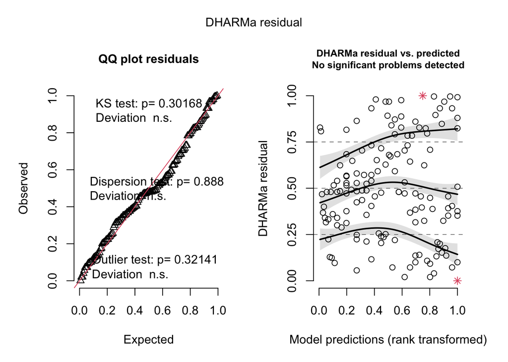

```
## Object of Class DHARMa with simulated residuals based on 250 simulations with refit = FALSE . See ?DHARMa::simulateResiduals for help.
##
## Scaled residual values: 0.468 0.368 0.34 0.828 0.316 0.808 0.128 0.4 0.48 0.48 0.124 0.096 0.224 0.332 0.36 0.516 0.54 0.3 0.34 0.48 ...
```

```r
simulateResiduals(mat5, plot=T)
```

```r
tab_model(mat5, show.intercept = F)
```

|  | mature_load/1e+07 |  |  |
| --- | --- | --- | --- |
| Predictors | Estimates | CI | p |
| Isolate [C1] | -0.70 | -1.46 – 0.06 | 0.071 |
| Isolate [C18] | -0.44 | -1.10 – 0.22 | 0.189 |
| Isolate [C24] | -0.35 | -1.03 – 0.33 | 0.308 |
| DeathAge | 0.01 | -0.00 – 0.02 | 0.122 |
| Isolate [C1] × DeathAge | 0.02 | 0.00 – 0.03 | **0.043** |
| Isolate [C18] × DeathAge | 0.01 | 0.00 – 0.03 | **0.028** |
| Isolate [C24] × DeathAge | 0.01 | -0.00 – 0.02 | 0.184 |
| Observations | 145 |  |  |
| R<sup>2</sup> / R<sup>2</sup> adjusted | 0.403 / 0.368 |  |  |

C1 and C18 have significantly increased growth speed over time compared to C14 (référence) and C24.

#### Visualisation

```
## Ignoring unknown labels:
## • fill : "Temperature (°C)"
```

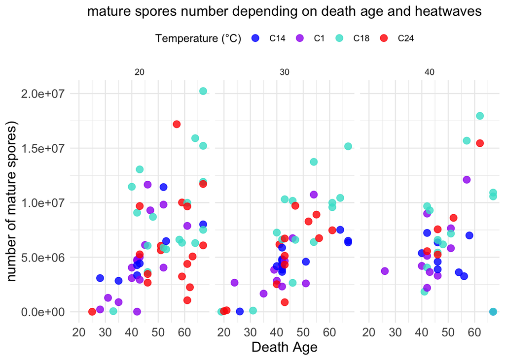

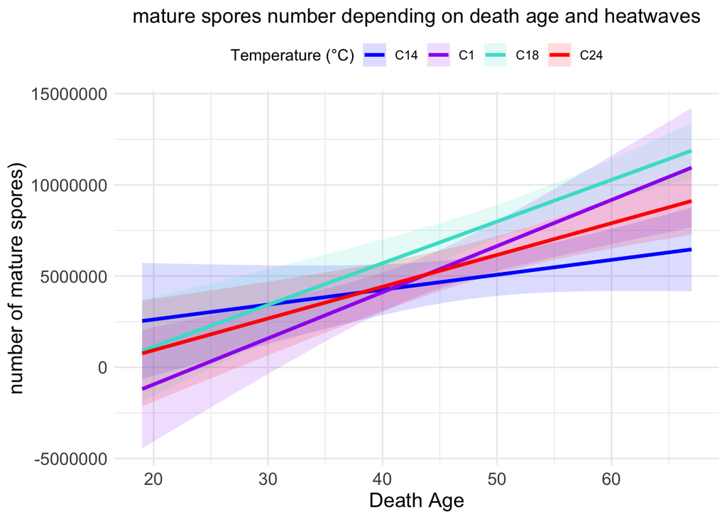

### 5.5 2nd cauliflowers

Cauliflowers can also be observed if parasites restart a second cycle inside the same host. Here we are interested in understanding how their presence/absence is affected by temperature and the genotype of the spores. We also investigated the potential impact of variations in time post-exposure, as all screened individuals died at different times.

```r
data_c2 = subset(infected, infected$cauliflowers!="counted-after-freezer" & infected$cauliflowers!="counted-after-freezer"& infected$stade_max!="Cauliflower")

data_c2$Temperature = factor(data_c2$Temperature, ordered = T)

Caul2 = glmmTMB(data=data_c2, cauliflowers~Temperature*Isolate+DeathAge, family = "binomial")
Caul2R = glmmTMB(data=data_c2, cauliflowers~Temperature*Isolate+DeathAge + (1|Batch), family = "binomial", REML= T)

AICc(Caul2, Caul2R)
```

```
##        df     AICc
## Caul2  13 207.2512
## Caul2R 14 207.1492
```

```r
Caul2.1 = glmmTMB(data=data_c2, cauliflowers~Temperature*Isolate*DeathAge, family = "binomial")

Caul2.2 = glmmTMB(data=data_c2, cauliflowers~Temperature+Isolate*DeathAge, family = "binomial")
Caul2.3 = glmmTMB(data=data_c2, cauliflowers~Temperature*Isolate+DeathAge, family = "binomial")
Caul2.4 = glmmTMB(data=data_c2, cauliflowers~Isolate+DeathAge*Temperature, family = "binomial")

Caul2.5 = glmmTMB(data=data_c2, cauliflowers~Isolate*DeathAge, family = "binomial")
Caul2.6 = glmmTMB(data=data_c2, cauliflowers~Temperature*Isolate, family = "binomial")
Caul2.7 = glmmTMB(data=data_c2, cauliflowers~DeathAge*Temperature, family = "binomial")

Caul2.8 = glmmTMB(data=data_c2, cauliflowers~Temperature+Isolate+DeathAge, family = "binomial")

Caul2.9 = glmmTMB(data=data_c2, cauliflowers~Isolate+DeathAge, family = "binomial")
Caul2.10 = glmmTMB(data=data_c2, cauliflowers~Temperature+Isolate, family = "binomial")
Caul2.11 = glmmTMB(data=data_c2, cauliflowers~DeathAge+Temperature, family = "binomial")

Caul2.12 = glmmTMB(data=data_c2, cauliflowers~DeathAge, family = "binomial")
Caul2.13 = glmmTMB(data=data_c2, cauliflowers~Isolate, family = "binomial")
Caul2.14 = glmmTMB(data=data_c2, cauliflowers~Temperature, family = "binomial")

Caul2.0 = glmmTMB(data=data_c2, cauliflowers~1, family = "binomial")

AICc(Caul2.1, Caul2.2, Caul2.3, Caul2.4, Caul2.5, Caul2.6, Caul2.7, Caul2.8, Caul2.9, Caul2.10, Caul2.11, Caul2.12, Caul2.13, Caul2.14, Caul2.0)
```

```
##          df     AICc
## Caul2.1  24 221.5962
## Caul2.2  10 206.3934
## Caul2.3  13 207.2512
## Caul2.4   9 206.1231
## Caul2.5   8 205.8774
## Caul2.6  12 205.5078
## Caul2.7   6 205.5147
## Caul2.8   7 201.9549
## Caul2.9   5 201.6345
## Caul2.10  6 201.1274
## Caul2.11  4 201.8077
## Caul2.12  2 201.3683
## Caul2.13  4 200.2414
## Caul2.14  3 199.9651
## Caul2.0   1 199.3769
```

```r
tab_model(Caul2.0, Caul2.14, Caul2.13, Caul2.12, Caul2.10, show.intercept = F)
```

|  | cauliflowers |  |  | cauliflowers |  |  | cauliflowers |  |  | cauliflowers |  |  | cauliflowers |  |  |
| --- | --- | --- | --- | --- | --- | --- | --- | --- | --- | --- | --- | --- | --- | --- | --- |
| Predictors | Odds Ratios | CI | p | Odds Ratios | CI | p | Odds Ratios | CI | p | Odds Ratios | CI | p | Odds Ratios | CI | p |
| Temperature [linear] |  |  |  | 1.06 | 0.60 – 1.89 | 0.837 |  |  |  |  |  |  | 1.04 | 0.58 – 1.89 | 0.891 |
| Temperature [quadratic] |  |  |  | 0.58 | 0.32 – 1.05 | 0.070 |  |  |  |  |  |  | 0.57 | 0.31 – 1.05 | 0.073 |
| Isolate [C1] |  |  |  |  |  |  | 0.91 | 0.32 – 2.61 | 0.858 |  |  |  | 0.98 | 0.33 – 2.85 | 0.965 |
| Isolate [C18] |  |  |  |  |  |  | 0.38 | 0.14 – 1.02 | 0.054 |  |  |  | 0.39 | 0.14 – 1.07 | 0.067 |
| Isolate [C24] |  |  |  |  |  |  | 0.69 | 0.25 – 1.94 | 0.488 |  |  |  | 0.72 | 0.25 – 2.05 | 0.535 |
| DeathAge |  |  |  |  |  |  |  |  |  | 1.00 | 0.98 – 1.03 | 0.799 |  |  |  |
| Observations | 145 |  |  | 145 |  |  | 145 |  |  | 145 |  |  | 145 |  |  |
| R<sup>2</sup> Tjur | 0.000 |  |  | 0.024 |  |  | 0.037 |  |  | 0.000 |  |  | 0.059 |  |  |

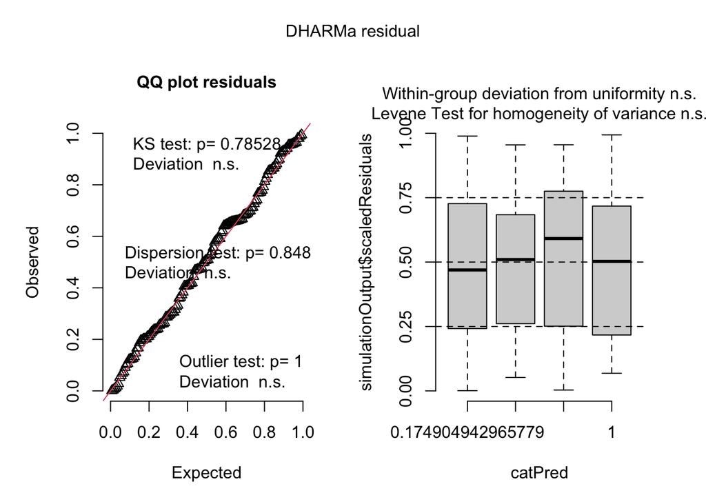

```
## Object of Class DHARMa with simulated residuals based on 250 simulations with refit = FALSE . See ?DHARMa::simulateResiduals for help.
##
## Scaled residual values: 0.2323121 0.4716365 0.7126411 0.6861518 0.2546818 0.3056335 0.645681 0.6405459 0.9225231 0.8999696 0.9554663 0.1963001 0.20196 0.6420615 0.6905008 0.00794358 0.1867782 0.665696 0.4064166 0.2371338 ...
```

```r
# No differences

simulateResiduals(Caul2.13, plot=T)
```

```r
tab_model(Caul2.10, show.intercept = F)
```

|  | cauliflowers |  |  |
| --- | --- | --- | --- |
| Predictors | Odds Ratios | CI | p |
| Temperature [linear] | 1.04 | 0.58 – 1.89 | 0.891 |
| Temperature [quadratic] | 0.57 | 0.31 – 1.05 | 0.073 |
| Isolate [C1] | 0.98 | 0.33 – 2.85 | 0.965 |
| Isolate [C18] | 0.39 | 0.14 – 1.07 | 0.067 |
| Isolate [C24] | 0.72 | 0.25 – 2.05 | 0.535 |
| Observations | 145 |  |  |
| R<sup>2</sup> Tjur | 0.059 |  |  |

We observed that the null model is among the best ones and that the measured effect are relatively low, so we preffered the model taking into account the effect of the genotype on the second cauliflower formation, which seem more biologically relevant, however it should be interptreted with caution.

#### Visualisation

```
## Ignoring unknown labels:
## • fill : "Temperature (°C)"
```

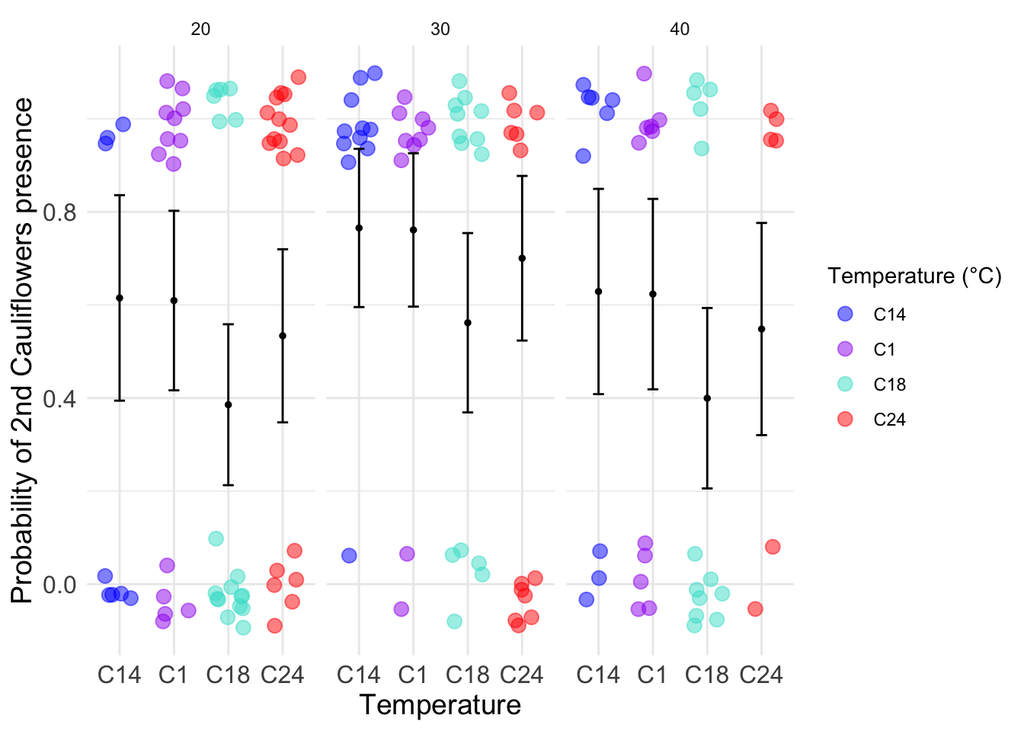

### 5.6 Maximal stage reached

The purpose of this section is to analyze the impact of temperature and parasite genotype on the maximum stage reached by the parasite at host death. We also included the impact of host age at death as individuals died at different times post-exposure.

```r
infected = subset(infected,stade_max!="None")
infected$stade_max = factor(infected$stade_max, ordered = T)
infected$Temperature = factor(infected$Temperature, ordered = T)

infected$stade_simplifie <- fct_collapse(infected$stade_max,
  "Caul_Grapes" = c("Cauliflower", "Grapes"),
  "Imm_Mature"  = c("Immature", "Mature"),
  "2nd_Caul"    = "2nd_Cauliflower"
)

infected$stade_simplifie <- factor(infected$stade_simplifie,
                                  levels = c("Caul_Grapes", "Imm_Mature", "2nd_Caul"),
                                  ordered = TRUE)

#modele13 = polr(stade_max ~ Temperature * Isolate * DeathAge, data = infected, Hess = TRUE)

modele14 = polr(stade_max ~ Temperature + Isolate + DeathAge, data = infected, Hess = TRUE)
modele14R = clmm(stade_max ~ Temperature + Isolate + DeathAge + (1 | Batch), data = infected)
AICc(modele14R, modele14) # No need for random factor
```

```
##           df     AICc
## modele14R 11 293.3242
## modele14  10 292.0298
```

```r
#modele1 = polr(stade_max ~ Temperature + Isolate * DeathAge, data = infected, Hess = TRUE)
modele2 = polr(stade_max ~ Temperature * Isolate + DeathAge, data = infected, Hess = TRUE)
modele3 = polr(stade_max ~ Isolate +  DeathAge * Temperature, data = infected, Hess = TRUE)

#modele4 = polr(stade_max ~ Isolate * DeathAge, data = infected, Hess = TRUE)
modele5 = polr(stade_max ~ Temperature * Isolate, data = infected, Hess = TRUE)
modele6 = polr(stade_max ~ DeathAge * Temperature, data = infected, Hess = TRUE)

modele7 = polr(stade_max ~ Isolate + DeathAge, data = infected, Hess = TRUE)
modele8 = polr(stade_max ~ Temperature + Isolate, data = infected, Hess = TRUE)
modele9 = polr(stade_max ~ DeathAge + Temperature, data = infected, Hess = TRUE)

modele10 = polr(stade_max ~ Temperature, data = infected, Hess = TRUE)
modele11 = polr(stade_max ~ Isolate, data = infected, Hess = TRUE)
modele12 = polr(stade_max ~ DeathAge, data = infected, Hess = TRUE)

modele0 = polr(stade_max ~ 1, data = infected, Hess = TRUE)

AICc(modele2,modele3,modele5,modele6,modele7,modele8,modele9,modele10,modele11,modele12,modele14,modele0)
```

```
##          df     AICc
## modele2  16 301.0434
## modele3  12 293.9404
## modele5  15 347.5868
## modele6   9 297.1830
## modele7   8 299.5568
## modele8   9 341.0864
## modele9   7 294.9343
## modele10  6 335.5819
## modele11  7 342.4234
## modele12  5 301.1638
## modele14 10 292.0298
## modele0   4 337.1707
```

```r
tab_model(modele14, modele3, modele9)
```

|  | stade_max |  |  | stade_max |  |  | stade_max |  |  |
| --- | --- | --- | --- | --- | --- | --- | --- | --- | --- |
| Predictors | Odds Ratios | CI | p | Odds Ratios | CI | p | Odds Ratios | CI | p |
| Cauliflower\|Grapes | 3.24 | 0.85 – 12.35 | 0.084 | 2.01 | 0.44 – 9.15 | 0.364 | 2.60 | 0.81 – 8.37 | 0.109 |
| Grapes\|Immature | 3.60 | 0.94 – 13.75 | 0.061 | 2.24 | 0.49 – 10.19 | 0.294 | 2.89 | 0.89 – 9.31 | 0.076 |
| Immature\|Mature | 4.40 | 1.14 – 16.94 | **0.032** | 2.75 | 0.60 – 12.52 | 0.190 | 3.52 | 1.08 – 11.43 | **0.037** |
| Mature\|2nd Cauliflower | 95.60 | 19.81 – 461.41 | **<0.001** | 61.98 | 11.36 – 338.24 | **<0.001** | 63.92 | 16.10 – 253.77 | **<0.001** |
| Temperature [linear] | 1.53 | 0.87 – 2.73 | 0.145 | 9.54 | 0.99 – 104.48 | 0.057 | 1.47 | 0.85 – 2.59 | 0.174 |
| Temperature [quadratic] | 0.42 | 0.23 – 0.76 | **0.006** | 0.93 | 0.09 – 9.70 | 0.949 | 0.45 | 0.25 – 0.81 | **0.009** |
| Isolate [C1] | 1.58 | 0.59 – 4.28 | 0.366 | 1.49 | 0.55 – 4.03 | 0.432 |  |  |  |
| Isolate [C18] | 0.39 | 0.15 – 1.02 | 0.060 | 0.36 | 0.13 – 0.94 | **0.042** |  |  |  |
| Isolate [C24] | 0.70 | 0.26 – 1.83 | 0.464 | 0.62 | 0.23 – 1.66 | 0.346 |  |  |  |
| DeathAge | 1.11 | 1.07 – 1.14 | **<0.001** | 1.10 | 1.06 – 1.14 | **<0.001** | 1.09 | 1.06 – 1.12 | **<0.001** |
| DeathAge × Temperature [linear] |  |  |  | 0.96 | 0.92 – 1.01 | 0.107 |  |  |  |
| DeathAge × Temperature [quadratic] |  |  |  | 0.98 | 0.93 – 1.03 | 0.517 |  |  |  |
| Observations | 162 |  |  | 162 |  |  | 162 |  |  |
| R<sup>2</sup> Nagelkerke | 0.348 |  |  | 0.362 |  |  | 0.299 |  |  |

```r
brant(modele14)
```

```
## --------------------------------------------
## Test for X2  df  probability
## --------------------------------------------
## Omnibus      16.1    18  0.59
## Temperature.L    4.04    3   0.26
## Temperature.Q    6.78    3   0.08
## IsolateC1    0.22    3   0.97
## IsolateC18   -461.22 3   1
## IsolateC24   2.63    3   0.45
## DeathAge 9.09    3   0.03
## --------------------------------------------
##
## H0: Parallel Regression Assumption holds
```

```r
# GSimplified stages
FC1 = polr(stade_simplifie ~ Isolate + Temperature * DeathAge,
                data = infected, Hess = TRUE)
model_selection = dredge(FC1)

model_selection
```

```
## Global model call: polr(formula = stade_simplifie ~ Isolate + Temperature * DeathAge,
##     data = infected, Hess = TRUE)
## ---
## Model selection table
##    (Int)     DtA Isl Tmp DtA:Tmp df   logLik  AICc delta weight
## 8      + 0.09511   +   +          8 -125.533 268.0  0.00  0.435
## 16     + 0.08670   +   +       + 10 -123.565 268.6  0.58  0.325
## 6      + 0.08108       +          5 -130.010 270.4  2.40  0.131
## 14     + 0.07302       +       +  7 -128.273 271.3  3.27  0.085
## 4      + 0.08703   +              6 -131.054 274.7  6.64  0.016
## 2      + 0.07531                  3 -134.837 275.8  7.82  0.009
## 5      +               +          4 -148.833 305.9 37.91  0.000
## 1      +                          2 -151.702 307.5 39.47  0.000
## 7      +           +   +          7 -148.297 311.3 43.31  0.000
## 3      +           +              5 -151.140 312.7 44.66  0.000
## Models ranked by AICc(x)
```

```r
models_within_2_AIC = subset(model_selection, delta < 2)
selected_models = get.models(models_within_2_AIC, 1:nrow(models_within_2_AIC))
tab_model(selected_models, show.intercept = F)
```

|  | stade_simplifie |  |  | stade_simplifie |  |  |
| --- | --- | --- | --- | --- | --- | --- |
| Predictors | Odds Ratios | CI | p | Odds Ratios | CI | p |
| Caul Grapes\|Imm Mature | 3.04 | 0.79 – 11.66 | 0.105 | 1.72 | 0.38 – 7.84 | 0.483 |
| Imm Mature\|2nd Caul | 71.72 | 15.03 – 342.18 | **<0.001** | 43.91 | 8.21 – 234.87 | **<0.001** |
| DeathAge | 1.10 | 1.07 – 1.14 | **<0.001** | 1.09 | 1.06 – 1.13 | **<0.001** |
| Isolate [C1] | 1.54 | 0.57 – 4.15 | 0.392 | 1.43 | 0.53 – 3.87 | 0.477 |
| Isolate [C18] | 0.40 | 0.15 – 1.03 | 0.063 | 0.36 | 0.13 – 0.94 | **0.042** |
| Isolate [C24] | 0.77 | 0.29 – 2.05 | 0.604 | 0.69 | 0.25 – 1.84 | 0.458 |
| Temperature [linear] | 1.57 | 0.89 – 2.82 | 0.126 | 14.72 | 1.41 – 164.42 | **0.028** |
| Temperature [quadratic] | 0.45 | 0.25 – 0.82 | **0.010** | 1.51 | 0.15 – 15.81 | 0.728 |
| DeathAge × Temperature [linear] |  |  |  | 0.95 | 0.91 – 1.00 | 0.056 |
| DeathAge × Temperature [quadratic] |  |  |  | 0.97 | 0.92 – 1.02 | 0.318 |
| Observations | 162 |  |  | 162 |  |  |
| R<sup>2</sup> Nagelkerke | 0.326 |  |  | 0.347 |  |  |

```r
best_mod = polr(stade_simplifie ~ Isolate + Temperature + DeathAge,
                data = infected, Hess = TRUE)
tab_model(best_mod)
```

|  | stade_simplifie |  |  |
| --- | --- | --- | --- |
| Predictors | Odds Ratios | CI | p |
| Caul Grapes\|Imm Mature | 3.04 | 0.79 – 11.66 | 0.105 |
| Imm Mature\|2nd Caul | 71.72 | 15.03 – 342.18 | **<0.001** |
| Isolate [C1] | 1.54 | 0.57 – 4.15 | 0.392 |
| Isolate [C18] | 0.40 | 0.15 – 1.03 | 0.063 |
| Isolate [C24] | 0.77 | 0.29 – 2.05 | 0.604 |
| Temperature [linear] | 1.57 | 0.89 – 2.82 | 0.126 |
| Temperature [quadratic] | 0.45 | 0.25 – 0.82 | **0.010** |
| DeathAge | 1.10 | 1.07 – 1.14 | **<0.001** |
| Observations | 162 |  |  |
| R<sup>2</sup> Nagelkerke | 0.326 |  |  |

```r
brant(best_mod) # Not much better, but same concluisons, so I kept the other one.
```

```
## --------------------------------------------
## Test for X2  df  probability
## --------------------------------------------
## Omnibus      12.46   6   0.05
## IsolateC1    0.04    1   0.85
## IsolateC18   0.97    1   0.32
## IsolateC24   1.41    1   0.24
## Temperature.L    1.19    1   0.28
## Temperature.Q    0.72    1   0.4
## DeathAge 9.95    1   0
## --------------------------------------------
##
## H0: Parallel Regression Assumption holds
```

```r
tab_model(modele14)
```

|  | stade_max |  |  |
| --- | --- | --- | --- |
| Predictors | Odds Ratios | CI | p |
| Cauliflower\|Grapes | 3.24 | 0.85 – 12.35 | 0.084 |
| Grapes\|Immature | 3.60 | 0.94 – 13.75 | 0.061 |
| Immature\|Mature | 4.40 | 1.14 – 16.94 | **0.032** |
| Mature\|2nd Cauliflower | 95.60 | 19.81 – 461.41 | **<0.001** |
| Temperature [linear] | 1.53 | 0.87 – 2.73 | 0.145 |
| Temperature [quadratic] | 0.42 | 0.23 – 0.76 | **0.006** |
| Isolate [C1] | 1.58 | 0.59 – 4.28 | 0.366 |
| Isolate [C18] | 0.39 | 0.15 – 1.02 | 0.060 |
| Isolate [C24] | 0.70 | 0.26 – 1.83 | 0.464 |
| DeathAge | 1.11 | 1.07 – 1.14 | **<0.001** |
| Observations | 162 |  |  |
| R<sup>2</sup> Nagelkerke | 0.348 |  |  |

#### Visualisation

[output not shown]

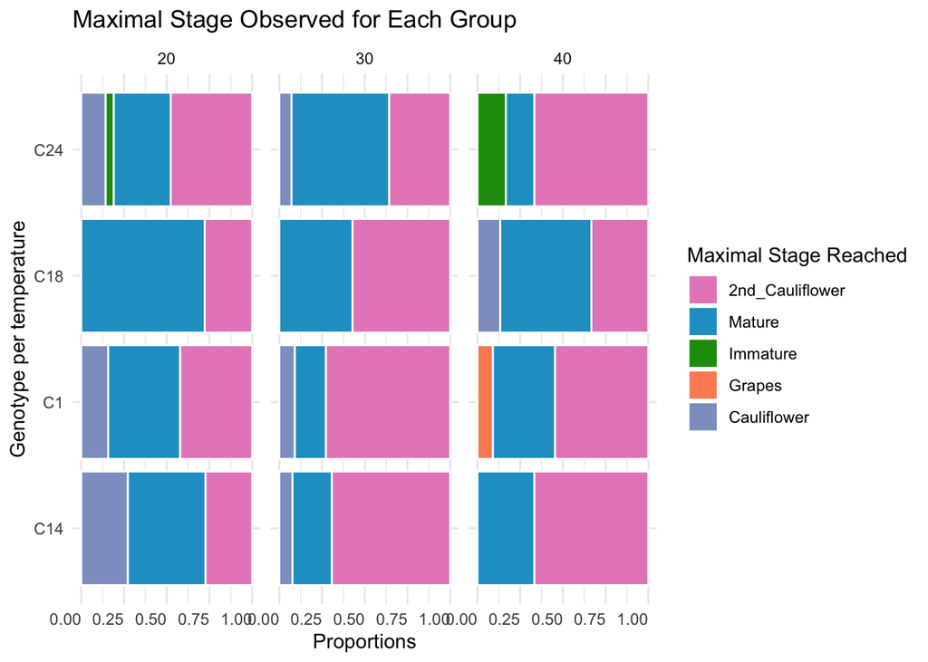

The quadratic effect of temperature (OR = 0.42, p = 0.006) indicates a non-linear relationship, where parasite maturation is optimal at intermediate temperatures (30°C) and decreases at both lower (20°C) and higher (40°C) extremes. At extreme temperatures, the odds of reaching a more advanced maturation stage decrease by 58%. There is also a non significant trend of a less efficient maturation for C18, which is consistent with the previous analysis for the second stage cauliflower formation.

##### Predicted composition per temperature

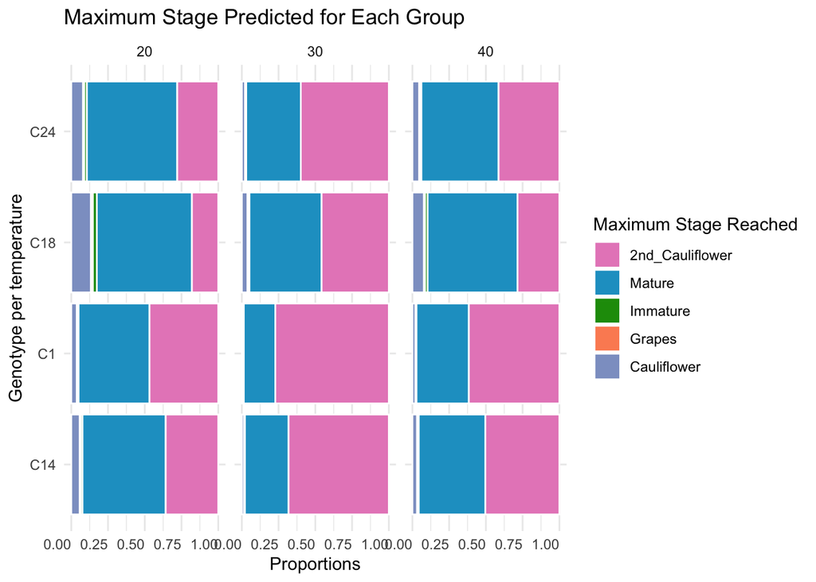